# 19BCE1717 Lab FAT

Makesh Srinivasan 19BCE1717

12/7/2021

# Question

CreditCard Format A data frame containing 1,319 observations on 12 variables. card Factor. Was the application for a credit card accepted? reports Number of major derogatory reports. age Age in years plus twelfths of a year. income Yearly income (in USD 10,000). share Ratio of monthly credit card expenditure to yearly income. expenditure Average monthly credit card expenditure. owner Factor. Does the individual own their home? selfemp Factor. Is the individual self-employed? dependents Number of dependents. months Months living at current address. majorcards Number of major credit cards held. active Number of active credit accounts. Provide appropriate inferences wherever necessary. Give suitable title, x-axis and y-axis labels in all graphs.

## ANSWER

##### Libraries

```r
library(ggplot2)
library(tidyverse)
library(MASS)
library(dplyr)
library(tidyr)
library(stringr)
library(caret)
library(lattice)
library(e1071)
```

# read the dataset

```r
data <- read.csv("CreditCard.csv")
```

# Part- A (35 marks)

#####1. Display the structure of the data set.

```r
str(data)
```

```
## 'data.frame':    1319 obs. of  13 variables:
##  $ X          : int  1 2 3 4 5 6 7 8 9 10 ...
##  $ card       : chr  "yes" "yes" "yes" "yes" ...
##  $ reports    : int  0 0 0 0 0 0 0 0 0 0 ...
##  $ age        : num  37.7 33.2 33.7 30.5 32.2 ...
##  $ income     : num  4.52 2.42 4.5 2.54 9.79 ...
##  $ share      : num  0.03327 0.00522 0.00416 0.06521 0.06705 ...
##  $ expenditure: num  124.98 9.85 15 137.87 546.5 ...
##  $ owner      : chr  "yes" "no" "yes" "no" ...
##  $ selfemp    : chr  "no" "no" "no" "no" ...
##  $ dependents : int  3 3 4 0 2 0 2 0 0 0 ...
##  $ months     : int  54 34 58 25 64 54 7 77 97 65 ...
##  $ majorcards : int  1 1 1 1 1 1 1 1 1 1 ...
##  $ active     : int  12 13 5 7 5 1 5 3 6 18 ...
```

#####2. Print random 10 observations in the data set.

```r
sample_n(data, 10)
```

```
##       X card reports      age income        share expenditure owner selfemp
## 1   308  yes       0 26.41667 3.5000 0.1319654000    384.8992    no      no
## 2   783   no       1 27.91667 2.8500 0.0004210526      0.0000    no      no
## 3   572  yes       0 33.16667 5.6000 0.0852958900    398.0475   yes      no
## 4   498   no       2 27.50000 1.8500 0.0006486487      0.0000    no      no
## 5   710   no       0 22.50000 1.8000 0.0006666667      0.0000    no      no
## 6  1292  yes       0 22.00000 1.7500 0.6214691000    906.3092    no      no
## 7   227   no       0 25.83333 3.9000 0.0003076923      0.0000    no      no
## 8   486   no       0 45.50000 6.5000 0.0001846154      0.0000    no      no
## 9   404  yes       0 35.75000 4.1400 0.1375309000    474.0650   yes      no
## 10  144   no       2 33.16667 2.3204 0.0005171522      0.0000    no      no
##    dependents months majorcards active
## 1           2     12          1      0
## 2           0     60          0      7
## 3           4     84          1      4
## 4           0     24          1     12
## 5           2      4          1      0
## 6           0      2          1      0
## 7           0     18          1      3
## 8           2     34          1      9
## 9           0     12          1     18
## 10          0     62          0      3
```

#####3. Display all the observations where the number of major derogatory reports is 3 or more. Print the observations satisfying the condition.

```r
d3 <- data%>%
  #major derogatory reports is 3 or more
  filter(reports >= 3)
# Print the observations satisfying the condition.
d3
```

```
##       X card reports      age income        share expenditure owner selfemp
## 1    18   no       7 29.50000 3.0000 0.0004000000      0.0000   yes      no
## 2    20   no       3 45.75000 3.4000 0.0003529412      0.0000    no      no
## 3    65   no       3 27.33333 4.9000 0.0002448980      0.0000   yes      no
## 4    85   no       3 40.16667 3.7099 0.0003234589      0.0000    no      no
## 5    94   no       4 35.16667 1.5000 0.0008000000      0.0000    no      no
## 6   115   no       3 25.91667 4.0000 0.0003000000      0.0000    no      no
## 7   121   no       4 23.41667 9.9999 0.0001200012      0.0000    no      no
## 8   131   no       5 31.08333 4.2000 0.0002857143      0.0000    no      no
## 9   150  yes       3 43.25000 6.7200 0.0314281200    175.9975   yes      no
## 10  154   no       5 27.16667 4.0000 0.0003000000      0.0000   yes      no
## 11  172   no       5 28.58333 3.1200 0.0003846154      0.0000    no      no
## 12  182   no       3 32.41667 2.0600 0.0005825243      0.0000    no      no
## 13  185   no       3 41.58333 4.6000 0.0002608696      0.0000    no      no
## 14  208   no       6 62.91667 2.5500 0.0004705882      0.0000    no      no
```

[output cut: 131 more lines]

#####4. Retrieve only the number of dependents of the card accepted applicants who own a house and live there for more than 5 years.

```r
# card accepted applicants, who own a house and live there for more than 5 years.
d4 <- data%>%
  filter(card=="yes" & months > 60 & owner=="yes") %>%
  dplyr::select(dependents)
d4
```

```
##     dependents
## 1            2
## 2            0
## 3            0
## 4            2
## 5            1
## 6            2
## 7            2
## 8            4
## 9            6
## 10           1
## 11           2
## 12           2
## 13           0
## 14           3
```

[output cut: 179 more lines]

```r
nrow(d4)
```

```
## [1] 193
```

#####5. Show the distribution of card accepted and rejected applicants using an appropriate chart and provide your inference.

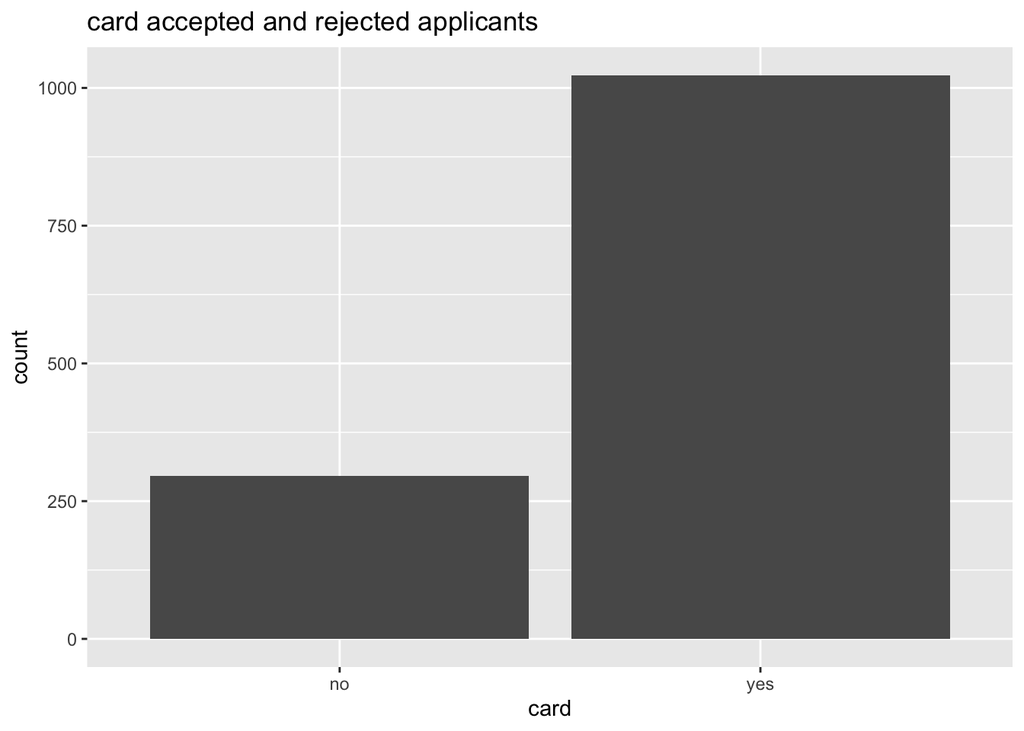

```r
ggplot(data, aes(x=card))+geom_bar()+ggtitle("card accepted and rejected applicants")
```

INFERENCE: The number of cards accepted people are more than the number of card rejected people as the height of the bar for “yes” is greater than the height of the bar corresponding to “no”.